# VU [183.653](https://tiss.tuwien.ac.at/course/courseDetails.xhtml?courseNr=183653) Methodical, industrial Software-Engineering using the Haskell **fun**ctional programming language

# Space Usage of strict `ByteString`s

- 9 word fixed overhead for **new** `ByteString`s *or*
- 5 word fixed overhead for **shared** copies existing `ByteString`s, *and*
- ⌈*N* / *w**o**r**d**s**i**z**e*⌉ words variable overhead for *N*-length string

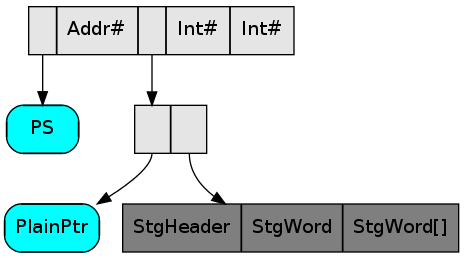

# Summary of strict `ByteString`s

- Good:
  - compact representation of byte arrays
  - provides pure, `Data.List`-like API
  - supports zero-copy slicing
  - *O*(1) indexing
- Not so good:
  - cons/append requires allocating a new `ByteArray` and copying everything over
  - unintended sharing can lead to resource leaks
  - fixed overhead is significant for short strings
  - Not suitable for handling Unicode strings

# Lazy `ByteString`s

- Basically, lazy list of strict `ByteString`s:

  ```haskell
  import qualified Data.ByteString as S

  data ByteString
      = Empty
      | Chunk {-# UNPACK #-} !S.ByteString ByteString
  ```

- `append` can share data from original lazy `ByteString`s (c.f. `(++)`/`[a]`)
- can be used for lazy I/O (but beware of the dangers of lazy I/O)
- converting from lazy `ByteString`s to strict `ByteString`s is expensive in general
- useful for buffering during serialization (-> bytestring/text builder concept)

# `Text`

- `Bytestring`s are perfect for 8bit character sets such as ASCII or ISO-8859-1
- But often need to operate on the full Unicode character set:
  - The Glyph "`€`" is described by (21-bit) **code point** `U+20AC`.
  - In **UTF-8** "`€`" is serialized to **three** 8-bit **code-units** "`0xE2 0x82 0xAC`".
  - In **UTF-16** "`€`" is serialized to **one** 16-bit code-unit "`0x20AC`".
  - In **UTF-8** "`$`" (`U+0024`) is serialized to **one** 8-bit code-unit "`0x24`".
  - **UTF-32** is constant-length encoding in 32-bit code-units.  
    (whereas UTF-8 and UTF-16 are variable-length encodings.)

# `Text` *(cont.)*

- Similiar concept as for `ByteString` but uses UTF-16 representation

```haskell
data Text = Text {-# UNPACK #-} !Array    -- payload
                 {-# UNPACK #-} !Int      -- offset
                 {-# UNPACK #-} !Int      -- length

data Array = Array ByteArray#   -- UTF-16 representation
```

- Due to the UTF-16 representation (-> *surrogate pairs*), operations such as `Text.length` becomes *O*(*n*) as it counts the number of code points (as opposed to number of UTF-16 code units)
- Fixed overhead of 6 words for **new** `Text`, 4 words for **shared** copies.

# `Integer` on the Heap

- The `Integer` type has internally two constructors which optimizes for "small" integers (`S#`) which fit into an `Int#`:

  ```haskell
  -- copied from GHC.Integer.Type
  data Integer
      = S# Int#
      | J# Int# ByteArray#
  ```

- Large integers (`J#`) are handled by the *GNU Multiple Precision Arithmetic Library* (GMP)
- `Integer` can't be unboxed or `UNPACK`ed

# `Data.Vector`

- A different way to represent a sequence of values instead of single-linked list `[a]` is to use an packed array of Pointers to `a`.
- That's what `Data.Vector` essentially does:

  ```haskell
  data Vector a = Vector {-# UNPACK #-} !Int
                         {-# UNPACK #-} !Int
                         {-# UNPACK #-} !(Array a)

  data Array a = Array (GHC.Prim.Array# a) -- array of pointers
  ```

# `Data.Vector` *(cont.)*

- Representing `Vector Int` on the heap takes up 6 + 3*N* words as `Vector` just stores an array of pointers to `I#` objects:

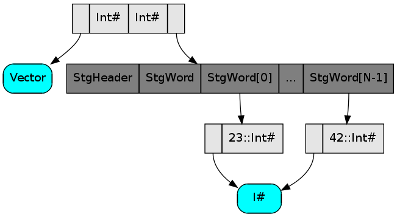

  Like for `Text` fixed overhead 6 words for **new** `Vector`s, 4 words for **shared** copies.

# `Data.Vector.Unboxed`

- Representing `[Int]` takes up 5*N* words, `Vector Int` still needs up to 6 + 3*N* words.
- With `Data.Vector.Unboxed` the `Int`s are stored directly in the `ByteArray#`, thus `U.Vector` has an overhead of 6 + *N* words!

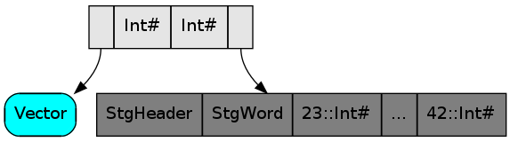